# Введение

Иногда при большой кандидатуре на должность, работодателю приходится выбирать более подходящих людей. В данной работе мы проанализируем какие данные сотрудника больше всего влияют на его поведение, если сказать точнее, то при каких условиях работники чаще всего нарушают дисциплину. Целевая функция Disciplinary failure (yes=1; no=0) – дисциплинарная ошибка показывает, нарушал ли сотрудник дисциплину на работе. Остальные атрибуты: Информация об атрибутах:

1. Индивидуальная идентификация (ID)
2. Причина отсутствия (ICD).
3. Месяц отсутствия
4. День недели (понедельник (2), вторник (3), среда (4), четверг (5), пятница (6))
5. Сезоны (лето (1), осень (2), зима (3), весна (4))
6. Транспортные расходы
7. Расстояние от места жительства до работы (в километрах)
8. Время обслуживания
9. Возраст
10. Рабочая нагрузка Средняя / день
11. Попадание в цель
12. Дисциплинарная ошибка (да = 1; нет = 0) - целевая
13. Образование (средняя школа (1), выпускник (2), аспирант (3), магистр и доктор (4))
14. Сын (количество детей)
15. Социальный пьющий (да = 1; нет = 0)
16. Социальный курильщик (да = 1; нет = 0)
17. Домашнее животное (количество домашних животных)
18. Вес
19. Высота
20. Индекс массы тела
21. Время прогулов в часах (цель)

Датасет: https://archive.ics.uci.edu/ml/datasets/Absenteeism+at+work

# Основная часть

# 1.Импорт библиотек и загрузка датасета

```python
import numpy as np
import pandas as pd
from IPython.core.display import display, HTML
display(HTML("<style>.container { width:95% !important; }</style>"))
from IPython.core.interactiveshell import InteractiveShell  #to run all statements in cell, not only the last
InteractiveShell.ast_node_interactivity = "all"
import matplotlib.pyplot as plt
from sklearn.preprocessing import LabelEncoder
import warnings
warnings.filterwarnings('ignore')
import seaborn as sns
from sklearn import preprocessing
from IPython.display import Image
from sklearn.model_selection import train_test_split
from sklearn.neighbors import KNeighborsClassifier
from sklearn.model_selection import GridSearchCV
from sklearn.metrics import accuracy_score
from sklearn.metrics import precision_score
from sklearn.preprocessing import MinMaxScaler
from sklearn.metrics import recall_score
from sklearn.metrics import confusion_matrix
from sklearn.model_selection import cross_val_score
from sklearn.tree import DecisionTreeClassifier
from sklearn.svm import LinearSVC
from sklearn.ensemble import BaggingClassifier
from sklearn.metrics import roc_curve, roc_auc_score
from xgboost import XGBClassifier
from sklearn.metrics import plot_confusion_matrix
import time
```

```python
# Отрисовка ROC-кривой
def draw_roc_curve(y_true, y_score, pos_label=1, average='micro'):
    fpr, tpr, thresholds = roc_curve(y_true, y_score,
                                     pos_label=pos_label)
    roc_auc_value = roc_auc_score(y_true, y_score, average=average)
    plt.figure()
    lw = 2
    plt.plot(fpr, tpr, color='darkorange',
             lw=lw, label='ROC curve (area = %0.2f)' % roc_auc_value)
    plt.plot([0, 1], [0, 1], color='navy', lw=lw, linestyle='--')
    plt.xlim([0.0, 1.0])
    plt.ylim([0.0, 1.05])
    plt.xlabel('False Positive Rate')
    plt.ylabel('True Positive Rate')
    plt.title('Receiver operating characteristic')
    plt.legend(loc="lower right")
    plt.show()
```

```python
data = pd.read_excel('data/Absenteeism_at_work.xlsx')
data.head(10)
data.shape #Размер данных
data.isnull().sum() #Проверим нулевые значения
data.describe() # Основные статистические характеристки набора данных
data["Disciplinary failure"].unique() #Проверяем значения целевого признака
```

|  | ID | Reason for absence | Month of absence | Day of the week | Seasons | Transportation expense | Distance from Residence to Work | Service time | Age | Work load Average/day | ... | Disciplinary failure | Education | Son | Social drinker | Social smoker | Pet | Weight | Height | Body mass index | Absenteeism time in hours |
| --- | --- | --- | --- | --- | --- | --- | --- | --- | --- | --- | --- | --- | --- | --- | --- | --- | --- | --- | --- | --- | --- |
| 0 | 11 | 26 | 7 | 3 | 1 | 289 | 36 | 13 | 33 | 239554 | ... | 0 | 1 | 2 | 1 | 0 | 1 | 90 | 172 | 30 | 4 |
| 1 | 36 | 0 | 7 | 3 | 1 | 118 | 13 | 18 | 50 | 239554 | ... | 1 | 1 | 1 | 1 | 0 | 0 | 98 | 178 | 31 | 0 |
| 2 | 3 | 23 | 7 | 4 | 1 | 179 | 51 | 18 | 38 | 239554 | ... | 0 | 1 | 0 | 1 | 0 | 0 | 89 | 170 | 31 | 2 |
| 3 | 7 | 7 | 7 | 5 | 1 | 279 | 5 | 14 | 39 | 239554 | ... | 0 | 1 | 2 | 1 | 1 | 0 | 68 | 168 | 24 | 4 |
| 4 | 11 | 23 | 7 | 5 | 1 | 289 | 36 | 13 | 33 | 239554 | ... | 0 | 1 | 2 | 1 | 0 | 1 | 90 | 172 | 30 | 2 |
| 5 | 3 | 23 | 7 | 6 | 1 | 179 | 51 | 18 | 38 | 239554 | ... | 0 | 1 | 0 | 1 | 0 | 0 | 89 | 170 | 31 | 2 |
| 6 | 10 | 22 | 7 | 6 | 1 | 361 | 52 | 3 | 28 | 239554 | ... | 0 | 1 | 1 | 1 | 0 | 4 | 80 | 172 | 27 | 8 |
| 7 | 20 | 23 | 7 | 6 | 1 | 260 | 50 | 11 | 36 | 239554 | ... | 0 | 1 | 4 | 1 | 0 | 0 | 65 | 168 | 23 | 4 |
| 8 | 14 | 19 | 7 | 2 | 1 | 155 | 12 | 14 | 34 | 239554 | ... | 0 | 1 | 2 | 1 | 0 | 0 | 95 | 196 | 25 | 40 |
| 9 | 1 | 22 | 7 | 2 | 1 | 235 | 11 | 14 | 37 | 239554 | ... | 0 | 3 | 1 | 0 | 0 | 1 | 88 | 172 | 29 | 8 |

10 rows × 21 columns

```
(740, 21)
```

```
ID                                 0
Reason for absence                 0
Month of absence                   0
Day of the week                    0
Seasons                            0
Transportation expense             0
Distance from Residence to Work    0
Service time                       0
Age                                0
Work load Average/day              0
Hit target                         0
Disciplinary failure               0
Education                          0
Son                                0
Social drinker                     0
Social smoker                      0
Pet                                0
Weight                             0
Height                             0
Body mass index                    0
Absenteeism time in hours          0
dtype: int64
```

|  | ID | Reason for absence | Month of absence | Day of the week | Seasons | Transportation expense | Distance from Residence to Work | Service time | Age | Work load Average/day | ... | Disciplinary failure | Education | Son | Social drinker | Social smoker | Pet | Weight | Height | Body mass index | Absenteeism time in hours |
| --- | --- | --- | --- | --- | --- | --- | --- | --- | --- | --- | --- | --- | --- | --- | --- | --- | --- | --- | --- | --- | --- |
| count | 740.000000 | 740.000000 | 740.000000 | 740.000000 | 740.000000 | 740.000000 | 740.000000 | 740.000000 | 740.000000 | 740.000000 | ... | 740.000000 | 740.000000 | 740.000000 | 740.000000 | 740.000000 | 740.000000 | 740.000000 | 740.000000 | 740.000000 | 740.000000 |
| mean | 18.017568 | 19.216216 | 6.324324 | 3.914865 | 2.544595 | 221.329730 | 29.631081 | 12.554054 | 36.450000 | 271490.235135 | ... | 0.054054 | 1.291892 | 1.018919 | 0.567568 | 0.072973 | 0.745946 | 79.035135 | 172.114865 | 26.677027 | 6.924324 |
| std | 11.021247 | 8.433406 | 3.436287 | 1.421675 | 1.111831 | 66.952223 | 14.836788 | 4.384873 | 6.478772 | 39058.116188 | ... | 0.226277 | 0.673238 | 1.098489 | 0.495749 | 0.260268 | 1.318258 | 12.883211 | 6.034995 | 4.285452 | 13.330998 |
| min | 1.000000 | 0.000000 | 0.000000 | 2.000000 | 1.000000 | 118.000000 | 5.000000 | 1.000000 | 27.000000 | 205917.000000 | ... | 0.000000 | 1.000000 | 0.000000 | 0.000000 | 0.000000 | 0.000000 | 56.000000 | 163.000000 | 19.000000 | 0.000000 |
| 25% | 9.000000 | 13.000000 | 3.000000 | 3.000000 | 2.000000 | 179.000000 | 16.000000 | 9.000000 | 31.000000 | 244387.000000 | ... | 0.000000 | 1.000000 | 0.000000 | 0.000000 | 0.000000 | 0.000000 | 69.000000 | 169.000000 | 24.000000 | 2.000000 |
| 50% | 18.000000 | 23.000000 | 6.000000 | 4.000000 | 3.000000 | 225.000000 | 26.000000 | 13.000000 | 37.000000 | 264249.000000 | ... | 0.000000 | 1.000000 | 1.000000 | 1.000000 | 0.000000 | 0.000000 | 83.000000 | 170.000000 | 25.000000 | 3.000000 |
| 75% | 28.000000 | 26.000000 | 9.000000 | 5.000000 | 4.000000 | 260.000000 | 50.000000 | 16.000000 | 40.000000 | 294217.000000 | ... | 0.000000 | 1.000000 | 2.000000 | 1.000000 | 0.000000 | 1.000000 | 89.000000 | 172.000000 | 31.000000 | 8.000000 |
| max | 36.000000 | 28.000000 | 12.000000 | 6.000000 | 4.000000 | 388.000000 | 52.000000 | 29.000000 | 58.000000 | 378884.000000 | ... | 1.000000 | 4.000000 | 4.000000 | 1.000000 | 1.000000 | 8.000000 | 108.000000 | 196.000000 | 38.000000 | 120.000000 |

8 rows × 21 columns

```
array([0, 1], dtype=int64)
```

# 2.Проведение разведочного анализа данных. Построение графиков, необходимых для понимания структуры данных. Анализ и заполнение пропусков в данных.

```python
data.dtypes
```

```
ID                                 int64
Reason for absence                 int64
Month of absence                   int64
Day of the week                    int64
Seasons                            int64
Transportation expense             int64
Distance from Residence to Work    int64
Service time                       int64
Age                                int64
Work load Average/day              int64
Hit target                         int64
Disciplinary failure               int64
Education                          int64
Son                                int64
Social drinker                     int64
Social smoker                      int64
Pet                                int64
Weight                             int64
Height                             int64
Body mass index                    int64
Absenteeism time in hours          int64
dtype: object
```

```python
data = data.drop(columns=['ID','Reason for absence','Month of absence','Day of the week',
       'Seasons', 'Work load Average/day ','Hit target','Education','Son','Pet','Social drinker',
       'Social smoker',
       'Absenteeism time in hours'],axis=1)
```

```python
data.dtypes
```

```
Transportation expense             int64
Distance from Residence to Work    int64
Service time                       int64
Age                                int64
Disciplinary failure               int64
Weight                             int64
Height                             int64
Body mass index                    int64
dtype: object
```

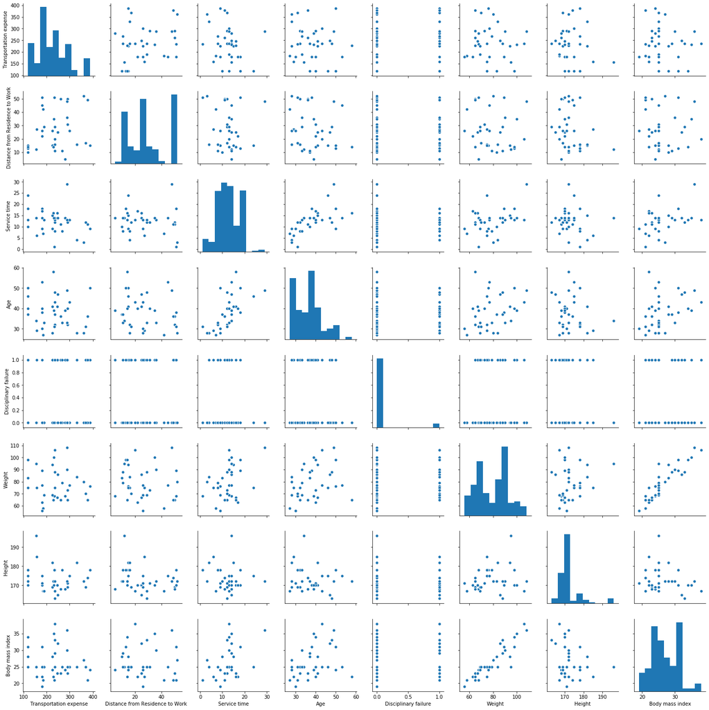

```python
sns.pairplot(data)
```

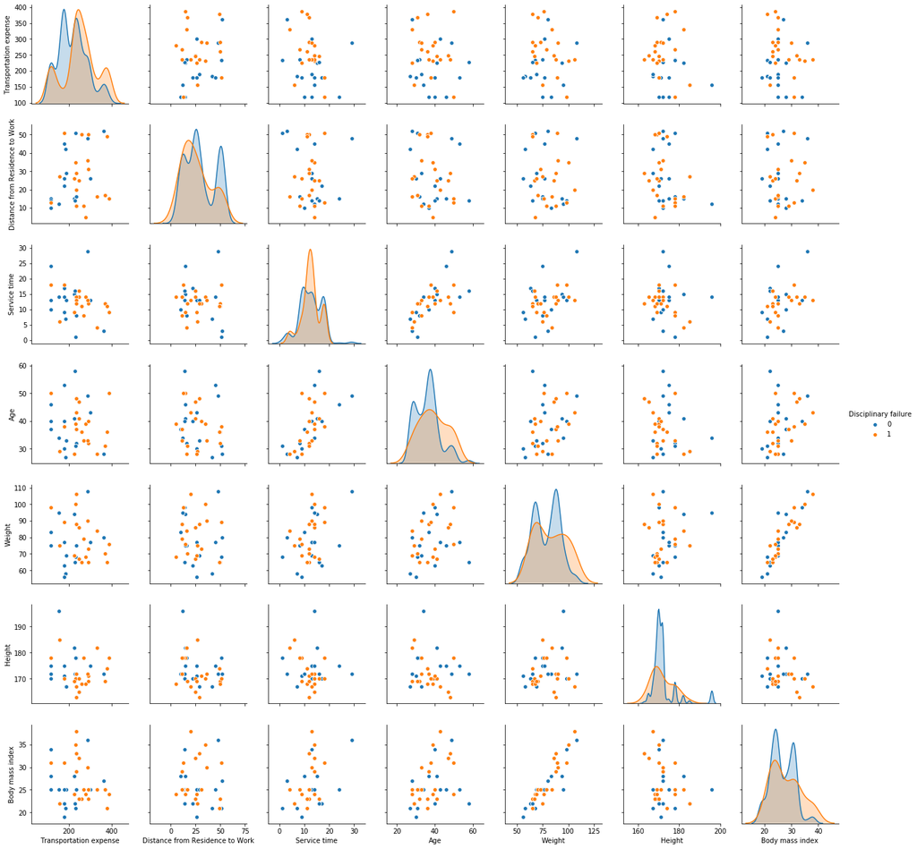

```python
sns.pairplot(data, hue="Disciplinary failure")
```

```python
# Убедимся, что целевой признак
# для задачи бинарной классификации содержит только 0 и 1
data['Disciplinary failure'].unique()
```

```
array([0, 1], dtype=int64)
```

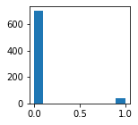

```python
# Оценим дисбаланс классов для Disciplinary failure
fig, ax = plt.subplots(figsize=(2,2))
plt.hist(data['Disciplinary failure'])
plt.show()
```

```python
data['Disciplinary failure'].value_counts()
```

```
0    700
1     40
Name: Disciplinary failure, dtype: int64
```

```python
total = data.shape[0]
class_0, class_1 = data['Disciplinary failure'].value_counts()
print('Класс 0 составляет {}%, а класс 1 составляет {}%.'
      .format(round(class_0 / total, 4)*100, round(class_1 / total, 4)*100))
```

```
Класс 0 составляет 94.59%, а класс 1 составляет 5.41%.
```

-Дисбаланс существенный

```python
data.columns
```

```
Index(['Transportation expense', 'Distance from Residence to Work',
       'Service time', 'Age', 'Disciplinary failure', 'Weight', 'Height',
       'Body mass index'],
      dtype='object')
```

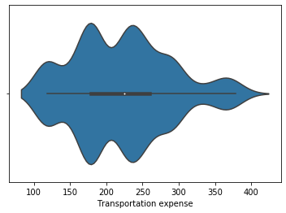

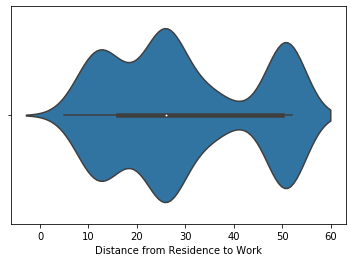

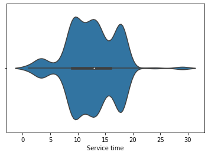

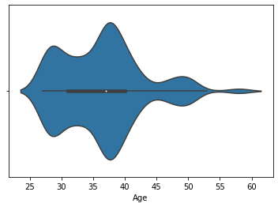

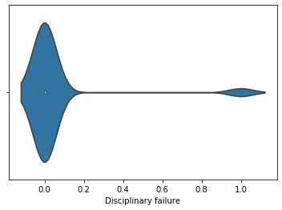

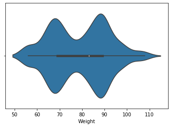

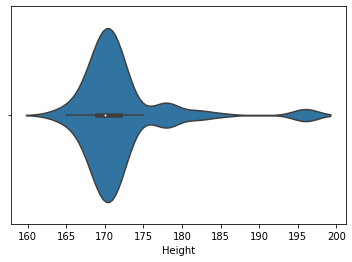

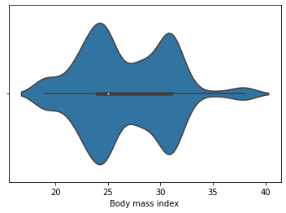

```python
# Скрипичные диаграммы для числовых колонок
for col in ['Transportation expense', 'Distance from Residence to Work',
       'Service time', 'Age', 'Disciplinary failure', 'Weight', 'Height',
       'Body mass index']:
    sns.violinplot(x=data[col])
    plt.show()
```

# 3.Выбор признаков, подходящих для построения моделей. Кодирование категориальных признаков. Масштабирование данных. Формирование вспомогательных признаков, улучшающих качество моделей.

```python
scale_cols = ['Transportation expense', 'Distance from Residence to Work',
       'Service time', 'Age', 'Disciplinary failure', 'Weight', 'Height',
       'Body mass index']
```

```python
sc1 = MinMaxScaler()
sc1_data = sc1.fit_transform(data[scale_cols])
```

```python
for i in range(len(scale_cols)):
    col = scale_cols[i]
    new_col_name = col + '_scaled'
    data[new_col_name] = sc1_data[:,i]
```

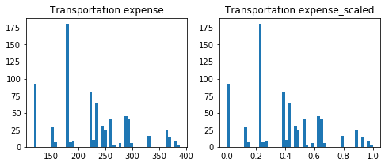

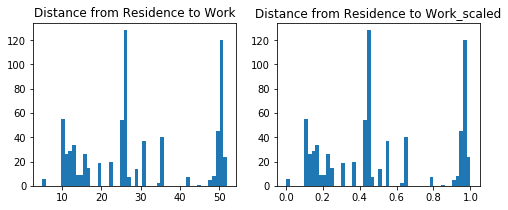

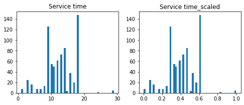

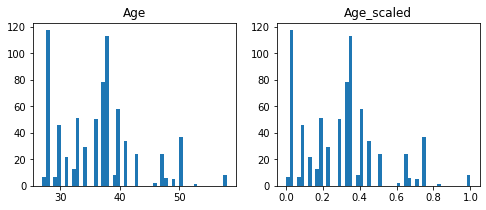

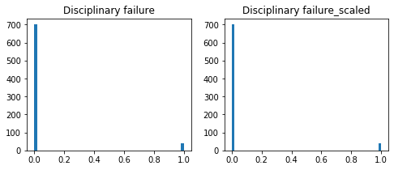

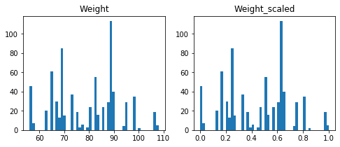

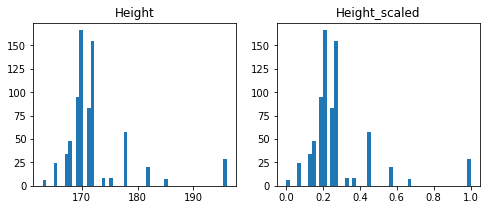

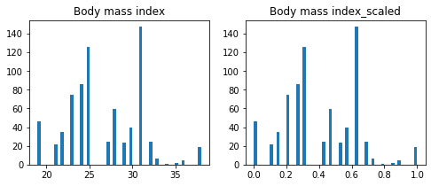

```python
for col in scale_cols:
    col_scaled = col + '_scaled'

    fig, ax = plt.subplots(1, 2, figsize=(8,3))
    ax[0].hist(data[col], 50)
    ax[1].hist(data[col_scaled], 50)
    ax[0].title.set_text(col)
    ax[1].title.set_text(col_scaled)
    plt.show()
```

# 4.Проведение корреляционного анализа данных. Формирование промежуточных выводов о возможности построения моделей машинного обучения.

```python
corr_cols_1 = scale_cols + ['Disciplinary failure']
corr_cols_1
```

```
['Transportation expense',
 'Distance from Residence to Work',
 'Service time',
 'Age',
 'Disciplinary failure',
 'Weight',
 'Height',
 'Body mass index',
 'Disciplinary failure']
```

```python
scale_cols_postfix = [x+'_scaled' for x in scale_cols]
corr_cols_2 = scale_cols_postfix + ['Disciplinary failure']
corr_cols_2
```

```
['Transportation expense_scaled',
 'Distance from Residence to Work_scaled',
 'Service time_scaled',
 'Age_scaled',
 'Disciplinary failure_scaled',
 'Weight_scaled',
 'Height_scaled',
 'Body mass index_scaled',
 'Disciplinary failure']
```

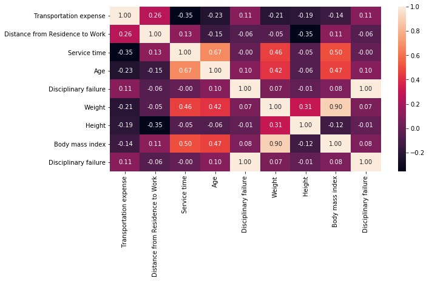

```python
fig, ax = plt.subplots(figsize=(10,5))
sns.heatmap(data[corr_cols_1].corr(), annot=True, fmt='.2f')
```

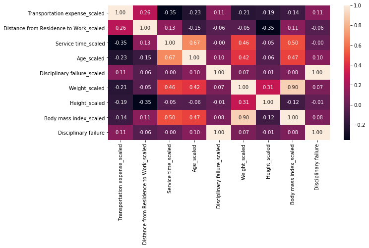

```python
fig, ax = plt.subplots(figsize=(10,5))
sns.heatmap(data[corr_cols_2].corr(), annot=True, fmt='.2f')
```

Вывод: Целевой признак не сильно коррелирует с осталными, но самые большие значения у Age и Transportation expense_scaled

```python
plt.figure(figsize=(15,10))

plt.subplot(2, 2, 1)
fig = data.Age.hist(bins=10)
fig.set_xlabel('Age')
fig.set_ylabel('Disciplinary failure')


plt.subplot(2, 2, 2)
fig = data.Weight.hist(bins=10)
fig.set_xlabel('Weight')
fig.set_ylabel('Disciplinary failure')
```

[output not shown]

# 5.Выбор метрик для последующей оценки качества моделей.

```python
class Metrics:
    def __init__(self):
        self.df=pd.DataFrame(
            {'metric':pd.Series([], dtype='str'),
             'alg':pd.Series([], dtype='str'),
             'value':pd.Series([], dtype='float')})

    def setv(self, metric, alg, value):
        self.df.drop(self.df[(self.df['metric']==metric)&(self.df['alg']==alg)].index, inplace=True)
        temp= [{'metric':metric, 'alg':alg, 'value':value}]
        self.df=self.df.append(temp, ignore_index=True)

    def getv(self, metric, ascending='True'):
        temp_data=self.df[self.df['metric']==metric]
        temp_data_2= temp_data.sort_values(by='value', ascending=ascending)
        return temp_data_2['alg'].values, temp_data_2['value'].values

    def plot(self, str_header, metric, ascending=True, figsize=(5,5)):
        array_labels, array_metric = self.getv(metric,ascending)
        fix, ax1 = plt.subplots(figsize=figsize)
        pos=np.arange(len(array_metric))
        rects = ax1.barh (pos, array_metric,
                         align='center',
                         height=0.5,
                         tick_label=array_labels)
        ax1.set_title(str_header)
        for a,b in zip(pos, array_metric):
            plt.text(0.5, a-0.05, str(round(b,3)),color='white')
        plt.show()
```

# 6.Формирование обучающей и тестовой выборок на основе исходного набора данных.

```python
features = data.drop(['Disciplinary failure'], axis=1)
target_tmp = data['Disciplinary failure']
target = pd.DataFrame({'Disciplinary failure':target_tmp.index, 'Disciplinary failure':target_tmp.values})
X_train, X_test, Y_train, Y_test = train_test_split(features, target, test_size=0.3, random_state=1)
X_train.shape
X_test.shape
Y_train.shape
Y_test.shape
```

```
(518, 15)
```

```
(222, 15)
```

```
(518, 1)
```

```
(222, 1)
```

# 7.Построение базового решения для выбранных моделей без подбора гиперпараметров. Производится обучение моделей на основе обучающей выборки и оценка качества моделей на основе тестовой выборки.

Выберем методы:

KNeighbors

DecisionTreeClassifier

LinearSVC

XGBoost

Bagging

Данные методы являются относительно быстрыми, а так же помогают получить решение разными методами.

```python
metric_logger = Metrics() #Запускаем класс логирования
def get_score(name,model,prediction):
    accuracy= accuracy_score(Y_test, prediction)
    precision= precision_score(Y_test, prediction)
    recall= recall_score(Y_test, prediction)
    print("accuracy_score: ", accuracy)
    print("precision_score: ", precision)
    print("recall_score: ", recall)
    metric_logger.setv("accuracy_score", name, accuracy)
    metric_logger.setv("precision_score", name, precision)
    metric_logger.setv("recall", name, recall)

def paint(model,prediction):
    draw_roc_curve(Y_test,prediction)
    plot_confusion_matrix(model, X_test, Y_test,
                      display_labels=['0','1'],
                      cmap=plt.cm.Blues, normalize='true')
```

```python
cl0_0 = KNeighborsClassifier().fit(X_train, Y_train)
target0_0 = cl0_0.predict(X_test)
cl0_0
target0_0
```

```
KNeighborsClassifier(algorithm='auto', leaf_size=30, metric='minkowski',
                     metric_params=None, n_jobs=None, n_neighbors=5, p=2,
                     weights='uniform')
```

```
array([0, 0, 0, 0, 0, 0, 0, 0, 0, 0, 0, 0, 0, 0, 0, 0, 0, 0, 0, 0, 0, 0,
       0, 0, 0, 0, 0, 0, 0, 0, 0, 0, 0, 0, 0, 0, 0, 0, 0, 0, 0, 0, 0, 0,
       0, 0, 0, 0, 0, 0, 0, 0, 0, 0, 0, 0, 0, 0, 0, 0, 0, 0, 1, 0, 0, 0,
       1, 0, 0, 0, 0, 0, 0, 0, 0, 0, 0, 0, 0, 0, 0, 0, 1, 0, 0, 0, 0, 0,
       0, 0, 0, 0, 0, 0, 0, 0, 0, 0, 0, 0, 0, 0, 0, 0, 0, 0, 0, 0, 0, 0,
       0, 0, 0, 0, 0, 0, 0, 0, 0, 0, 0, 0, 0, 0, 0, 0, 0, 0, 0, 0, 0, 0,
       0, 0, 0, 0, 0, 0, 0, 0, 0, 0, 0, 0, 0, 0, 0, 0, 0, 0, 0, 0, 0, 0,
       0, 0, 0, 0, 0, 0, 0, 0, 0, 0, 0, 0, 0, 1, 0, 0, 1, 0, 0, 0, 0, 0,
       0, 0, 0, 0, 0, 1, 0, 0, 0, 0, 0, 0, 0, 0, 0, 0, 0, 0, 0, 0, 0, 0,
       0, 0, 0, 0, 0, 0, 0, 0, 0, 0, 0, 0, 0, 0, 0, 0, 0, 0, 0, 0, 0, 0,
       0, 0], dtype=int64)
```

```
accuracy_score:  0.9504504504504504
precision_score:  0.3333333333333333
recall_score:  0.2222222222222222
```

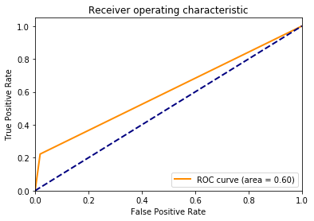

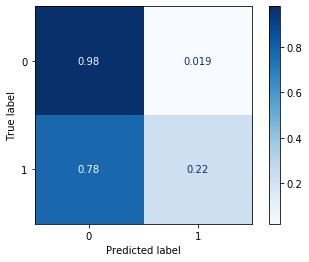

```python
get_score('KNeighbors_base',cl0_0,target0_0)
paint(cl0_0,target0_0)
```

```python
cl1_0 = DecisionTreeClassifier(max_depth=None).fit(X_train, Y_train)
target1_0 = cl1_0.predict(X_test)
cl1_0
target1_0
```

```
DecisionTreeClassifier(ccp_alpha=0.0, class_weight=None, criterion='gini',
                       max_depth=None, max_features=None, max_leaf_nodes=None,
                       min_impurity_decrease=0.0, min_impurity_split=None,
                       min_samples_leaf=1, min_samples_split=2,
                       min_weight_fraction_leaf=0.0, presort='deprecated',
                       random_state=None, splitter='best')
```

```
array([0, 0, 0, 0, 0, 0, 0, 0, 0, 0, 0, 0, 0, 0, 1, 0, 0, 0, 0, 0, 0, 0,
       0, 0, 0, 0, 0, 0, 0, 0, 0, 0, 0, 0, 0, 0, 0, 0, 0, 0, 0, 0, 0, 0,
       1, 0, 0, 0, 0, 0, 0, 0, 0, 0, 0, 0, 0, 0, 0, 0, 0, 0, 0, 0, 0, 0,
       1, 1, 0, 0, 0, 0, 0, 0, 0, 0, 0, 0, 0, 0, 0, 0, 0, 0, 0, 0, 0, 0,
       0, 0, 0, 0, 0, 0, 0, 0, 0, 0, 0, 0, 0, 0, 0, 0, 0, 0, 0, 0, 0, 0,
       0, 0, 0, 0, 0, 0, 0, 0, 0, 0, 0, 0, 0, 0, 0, 0, 0, 0, 0, 0, 0, 0,
       0, 0, 0, 0, 0, 0, 0, 0, 0, 0, 0, 0, 0, 0, 0, 0, 0, 0, 0, 0, 0, 0,
       0, 0, 0, 0, 0, 0, 0, 1, 0, 0, 0, 0, 0, 0, 0, 0, 1, 0, 0, 0, 0, 0,
       0, 0, 0, 0, 0, 0, 0, 0, 1, 0, 0, 0, 0, 0, 0, 0, 0, 0, 0, 0, 0, 0,
       0, 0, 0, 0, 0, 0, 0, 0, 0, 0, 0, 0, 1, 0, 0, 0, 0, 0, 0, 0, 0, 0,
       1, 0], dtype=int64)
```

```python
get_score('Decision_base',cl1_0,target1_0)
paint(cl1_0,target1_0)
```

[output not shown]

```
accuracy_score:  1.0
precision_score:  1.0
recall_score:  1.0
```

```python
cl2_0 = LinearSVC(C=1.0, penalty='l1', dual=False, max_iter=10000, ).fit(X_train, Y_train)
target2_0 = cl2_0.predict(X_test)
cl2_0
target2_0
```

```
LinearSVC(C=1.0, class_weight=None, dual=False, fit_intercept=True,
          intercept_scaling=1, loss='squared_hinge', max_iter=10000,
          multi_class='ovr', penalty='l1', random_state=None, tol=0.0001,
          verbose=0)
```

```
array([0, 0, 0, 0, 0, 0, 0, 0, 0, 0, 0, 0, 0, 0, 1, 0, 0, 0, 0, 0, 0, 0,
       0, 0, 0, 0, 0, 0, 0, 0, 0, 0, 0, 0, 0, 0, 0, 0, 0, 0, 0, 0, 0, 0,
       1, 0, 0, 0, 0, 0, 0, 0, 0, 0, 0, 0, 0, 0, 0, 0, 0, 0, 0, 0, 0, 0,
       1, 1, 0, 0, 0, 0, 0, 0, 0, 0, 0, 0, 0, 0, 0, 0, 0, 0, 0, 0, 0, 0,
       0, 0, 0, 0, 0, 0, 0, 0, 0, 0, 0, 0, 0, 0, 0, 0, 0, 0, 0, 0, 0, 0,
       0, 0, 0, 0, 0, 0, 0, 0, 0, 0, 0, 0, 0, 0, 0, 0, 0, 0, 0, 0, 0, 0,
       0, 0, 0, 0, 0, 0, 0, 0, 0, 0, 0, 0, 0, 0, 0, 0, 0, 0, 0, 0, 0, 0,
       0, 0, 0, 0, 0, 0, 0, 1, 0, 0, 0, 0, 0, 0, 0, 0, 1, 0, 0, 0, 0, 0,
       0, 0, 0, 0, 0, 0, 0, 0, 1, 0, 0, 0, 0, 0, 0, 0, 0, 0, 0, 0, 0, 0,
       0, 0, 0, 0, 0, 0, 0, 0, 0, 0, 0, 0, 1, 0, 0, 0, 0, 0, 0, 0, 0, 0,
       1, 0], dtype=int64)
```

```python
get_score('Linear_base',cl2_0,target2_0)
paint(cl2_0,target2_0)
```

[output not shown]

```
accuracy_score:  1.0
precision_score:  1.0
recall_score:  1.0
```

```python
cl3_0 = XGBClassifier().fit(X_train, Y_train)
target3_0 = cl3_0.predict(X_test)
cl3_0
target3_0
```

```
XGBClassifier(base_score=0.5, booster='gbtree', colsample_bylevel=1,
              colsample_bynode=1, colsample_bytree=1, gamma=0, gpu_id=-1,
              importance_type='gain', interaction_constraints='',
              learning_rate=0.300000012, max_delta_step=0, max_depth=6,
              min_child_weight=1, missing=nan, monotone_constraints='()',
              n_estimators=100, n_jobs=0, num_parallel_tree=1,
              objective='binary:logistic', random_state=0, reg_alpha=0,
              reg_lambda=1, scale_pos_weight=1, subsample=1,
              tree_method='exact', validate_parameters=1, verbosity=None)
```

```
array([0, 0, 0, 0, 0, 0, 0, 0, 0, 0, 0, 0, 0, 0, 1, 0, 0, 0, 0, 0, 0, 0,
       0, 0, 0, 0, 0, 0, 0, 0, 0, 0, 0, 0, 0, 0, 0, 0, 0, 0, 0, 0, 0, 0,
       1, 0, 0, 0, 0, 0, 0, 0, 0, 0, 0, 0, 0, 0, 0, 0, 0, 0, 0, 0, 0, 0,
       1, 1, 0, 0, 0, 0, 0, 0, 0, 0, 0, 0, 0, 0, 0, 0, 0, 0, 0, 0, 0, 0,
       0, 0, 0, 0, 0, 0, 0, 0, 0, 0, 0, 0, 0, 0, 0, 0, 0, 0, 0, 0, 0, 0,
       0, 0, 0, 0, 0, 0, 0, 0, 0, 0, 0, 0, 0, 0, 0, 0, 0, 0, 0, 0, 0, 0,
       0, 0, 0, 0, 0, 0, 0, 0, 0, 0, 0, 0, 0, 0, 0, 0, 0, 0, 0, 0, 0, 0,
       0, 0, 0, 0, 0, 0, 0, 1, 0, 0, 0, 0, 0, 0, 0, 0, 1, 0, 0, 0, 0, 0,
       0, 0, 0, 0, 0, 0, 0, 0, 1, 0, 0, 0, 0, 0, 0, 0, 0, 0, 0, 0, 0, 0,
       0, 0, 0, 0, 0, 0, 0, 0, 0, 0, 0, 0, 1, 0, 0, 0, 0, 0, 0, 0, 0, 0,
       1, 0], dtype=int64)
```

```python
get_score('XGBoost_base',cl3_0,target3_0)
paint(cl3_0,target3_0)
```

[output not shown]

```
accuracy_score:  1.0
precision_score:  1.0
recall_score:  1.0
```

```python
cl4_0 = BaggingClassifier().fit(X_train, Y_train)
target4_0 = cl4_0.predict(X_test)
cl4_0
target4_0
```

```
BaggingClassifier(base_estimator=None, bootstrap=True, bootstrap_features=False,
                  max_features=1.0, max_samples=1.0, n_estimators=10,
                  n_jobs=None, oob_score=False, random_state=None, verbose=0,
                  warm_start=False)
```

```
array([0, 0, 0, 0, 0, 0, 0, 0, 0, 0, 0, 0, 0, 0, 1, 0, 0, 0, 0, 0, 0, 0,
       0, 0, 0, 0, 0, 0, 0, 0, 0, 0, 0, 0, 0, 0, 0, 0, 0, 0, 0, 0, 0, 0,
       1, 0, 0, 0, 0, 0, 0, 0, 0, 0, 0, 0, 0, 0, 0, 0, 0, 0, 0, 0, 0, 0,
       1, 1, 0, 0, 0, 0, 0, 0, 0, 0, 0, 0, 0, 0, 0, 0, 0, 0, 0, 0, 0, 0,
       0, 0, 0, 0, 0, 0, 0, 0, 0, 0, 0, 0, 0, 0, 0, 0, 0, 0, 0, 0, 0, 0,
       0, 0, 0, 0, 0, 0, 0, 0, 0, 0, 0, 0, 0, 0, 0, 0, 0, 0, 0, 0, 0, 0,
       0, 0, 0, 0, 0, 0, 0, 0, 0, 0, 0, 0, 0, 0, 0, 0, 0, 0, 0, 0, 0, 0,
       0, 0, 0, 0, 0, 0, 0, 1, 0, 0, 0, 0, 0, 0, 0, 0, 1, 0, 0, 0, 0, 0,
       0, 0, 0, 0, 0, 0, 0, 0, 1, 0, 0, 0, 0, 0, 0, 0, 0, 0, 0, 0, 0, 0,
       0, 0, 0, 0, 0, 0, 0, 0, 0, 0, 0, 0, 1, 0, 0, 0, 0, 0, 0, 0, 0, 0,
       1, 0], dtype=int64)
```

```python
get_score('Bagging_base',cl4_0,target4_0)
paint(cl4_0,target4_0)
```

[output not shown]

```
accuracy_score:  1.0
precision_score:  1.0
recall_score:  1.0
```

# 8.Подбор гиперпараметров для выбранных моделей.

```python
%%time

n_range = np.array(range(1,100,1))
tuned_parameters = [{'n_neighbors': n_range}]
print (tuned_parameters)
optimazer_0 = GridSearchCV(KNeighborsClassifier(), tuned_parameters, cv = 5).fit(X_train, Y_train)
print (optimazer_0.best_score_)
print (optimazer_0.best_params_)
```

```
[{'n_neighbors': array([ 1,  2,  3,  4,  5,  6,  7,  8,  9, 10, 11, 12, 13, 14, 15, 16, 17,
       18, 19, 20, 21, 22, 23, 24, 25, 26, 27, 28, 29, 30, 31, 32, 33, 34,
       35, 36, 37, 38, 39, 40, 41, 42, 43, 44, 45, 46, 47, 48, 49, 50, 51,
       52, 53, 54, 55, 56, 57, 58, 59, 60, 61, 62, 63, 64, 65, 66, 67, 68,
       69, 70, 71, 72, 73, 74, 75, 76, 77, 78, 79, 80, 81, 82, 83, 84, 85,
       86, 87, 88, 89, 90, 91, 92, 93, 94, 95, 96, 97, 98, 99])}]
0.9768110530246453
{'n_neighbors': 1}
Wall time: 9.25 s
```

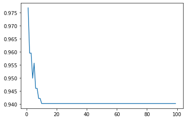

```python
y_range=np.array(optimazer_0.cv_results_['mean_test_score'])
plt.plot(n_range, y_range)
```

```python
%%time

n_range1 = np.array(range(1,70,1))
tuned_parameters1 = [{'max_depth': n_range1}]
optimazer_1 = GridSearchCV(DecisionTreeClassifier(), tuned_parameters1, cv = 5).fit(X_train, Y_train)
print (optimazer_1.best_score_)
print (optimazer_1.best_params_)
```

```
1.0
{'max_depth': 1}
Wall time: 2.66 s
```

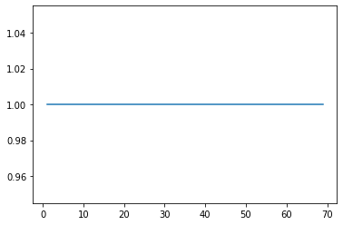

```python
y_range1=np.array(optimazer_1.cv_results_['mean_test_score'])
plt.plot(n_range1, y_range1)
```

```python
%%time

n_range2 = np.arange(0.001, 1.5, 0.005)
tuned_parameters2 = [{'C': n_range2}]
#tuned_parameters2_1 = [{'tol': n_range2_1}]
optimazer_2 = GridSearchCV(LinearSVC(), tuned_parameters2, cv = 5).fit(X_train, Y_train)
print (optimazer_2.best_score_)
print (optimazer_2.best_params_)
```

```
0.9440440627333831
{'C': 0.006}
Wall time: 1min 30s
```

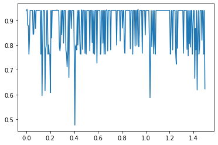

```python
y_range2=np.array(optimazer_2.cv_results_['mean_test_score'])
plt.plot(n_range2, y_range2)
```

```python
%%time


n_estimators = [50, 100, 150,200]
max_depth = [2, 4, 6, 8]
learning_rate = [0.01, 0.1, 0.2, 0.3]
tuned_parameters3 = dict(max_depth=max_depth, n_estimators=n_estimators, learning_rate=learning_rate)

optimazer_3 = GridSearchCV(XGBClassifier(), tuned_parameters3, cv = 5).fit(X_train, Y_train)

print (optimazer_3.best_score_)
print (optimazer_3.best_params_)
```

```
1.0
{'learning_rate': 0.01, 'max_depth': 2, 'n_estimators': 50}
Wall time: 22.6 s
```

```python
optimazer_3.cv_results_
```

[output not shown]

[output cut: 142 more lines]

[output not shown]

```python
%%time
n_estimators4 = [20, 50, 100, 150, 200, 250]
tuned_parameters4 = [{'n_estimators': n_estimators4}]
optimazer_4 = GridSearchCV(BaggingClassifier(), tuned_parameters4, cv = 5).fit(X_train, Y_train)
print (optimazer_4.best_score_)
print (optimazer_4.best_params_)
```

```
1.0
{'n_estimators': 20}
Wall time: 13.8 s
```

```
{'mean_fit_time': array([0.07072158, 0.20788922, 0.27898731, 0.45875835, 0.62413116,
        0.89777803]),
 'std_fit_time': array([0.00815477, 0.02836091, 0.02156647, 0.01436434, 0.06284819,
        0.14643006]),
 'mean_score_time': array([0.00757771, 0.01775179, 0.01935463, 0.05287743, 0.05184183,
        0.0619904 ]),
 'std_score_time': array([0.00195584, 0.00798828, 0.00149927, 0.03061406, 0.0187573 ,
        0.01983625]),
 'param_n_estimators': masked_array(data=[20, 50, 100, 150, 200, 250],
              mask=[False, False, False, False, False, False],
        fill_value='?',
             dtype=object),
 'params': [{'n_estimators': 20},
  {'n_estimators': 50},
  {'n_estimators': 100},
  {'n_estimators': 150},
  {'n_estimators': 200},
  {'n_estimators': 250}],
 'split0_test_score': array([1., 1., 1., 1., 1., 1.]),
 'split1_test_score': array([1., 1., 1., 1., 1., 1.]),
 'split2_test_score': array([1., 1., 1., 1., 1., 1.]),
 'split3_test_score': array([1., 1., 1., 1., 1., 1.]),
 'split4_test_score': array([1., 1., 1., 1., 1., 1.]),
 'mean_test_score': array([1., 1., 1., 1., 1., 1.]),
 'std_test_score': array([0., 0., 0., 0., 0., 0.]),
 'rank_test_score': array([1, 1, 1, 1, 1, 1])}
```

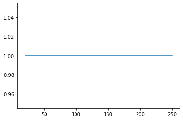

```python
optimazer_4.cv_results_
y_range4=np.array(optimazer_4.cv_results_['mean_test_score'])
plt.plot(n_estimators4, y_range4)
```